# WEEK 5: Dimensionality reduction techniques

In this exercise I was using data sets of human development and gender inequality. See the details from [this link](http://hdr.undp.org/en/content/human-development-index-hdi).

```r
# Set working directory:
setwd("C:/Users/mikniemi/OneDrive - University of Helsinki/OpenDataScience/IODS/IODS-project")

# Access the necessary tool packages:
library(dplyr)
library(corrplot)
library(GGally)
library(FactoMineR)
library(ggplot2)
library(tidyr)

# Load and explore the exercise data:
human <- read.table("Data/human.txt")
summary(human)
```

```
##   Edu2.Female     Labour.Female   Expected.Education Expected.Life
##  Min.   :  0.90   Min.   :13.50   Min.   : 5.40      Min.   :49.00
##  1st Qu.: 27.15   1st Qu.:44.45   1st Qu.:11.25      1st Qu.:66.30
##  Median : 56.60   Median :53.50   Median :13.50      Median :74.20
##  Mean   : 55.37   Mean   :52.52   Mean   :13.18      Mean   :71.65
##  3rd Qu.: 85.15   3rd Qu.:61.90   3rd Qu.:15.20      3rd Qu.:77.25
##  Max.   :100.00   Max.   :88.10   Max.   :20.20      Max.   :83.50
##       GNI         Maternal_mortality Adolescent_birth Woman_rep.Parliament
##  Min.   :   581   Min.   :   1.0     Min.   :  0.60   Min.   : 0.00
##  1st Qu.:  4198   1st Qu.:  11.5     1st Qu.: 12.65   1st Qu.:12.40
##  Median : 12040   Median :  49.0     Median : 33.60   Median :19.30
##  Mean   : 17628   Mean   : 149.1     Mean   : 47.16   Mean   :20.91
##  3rd Qu.: 24512   3rd Qu.: 190.0     3rd Qu.: 71.95   3rd Qu.:27.95
##  Max.   :123124   Max.   :1100.0     Max.   :204.80   Max.   :57.50
```

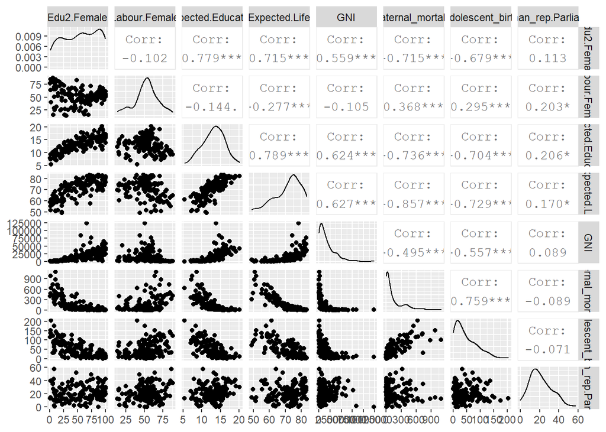

```r
ggpairs(human)
```

There are in total 8 variables explaining human development: 1) **Percentage of females having secondary education**, 2) **Percentage of females being employed**, 3) **Expected years of schooling**, 4) **Expected life**, 5) **The gross national income (GNI) Index**, 6) **Maternal mortality**, 7) **Adolescent birth**, and 8) **Female representation in parliament**. The figure above illustrates correlations between each pair of variables.

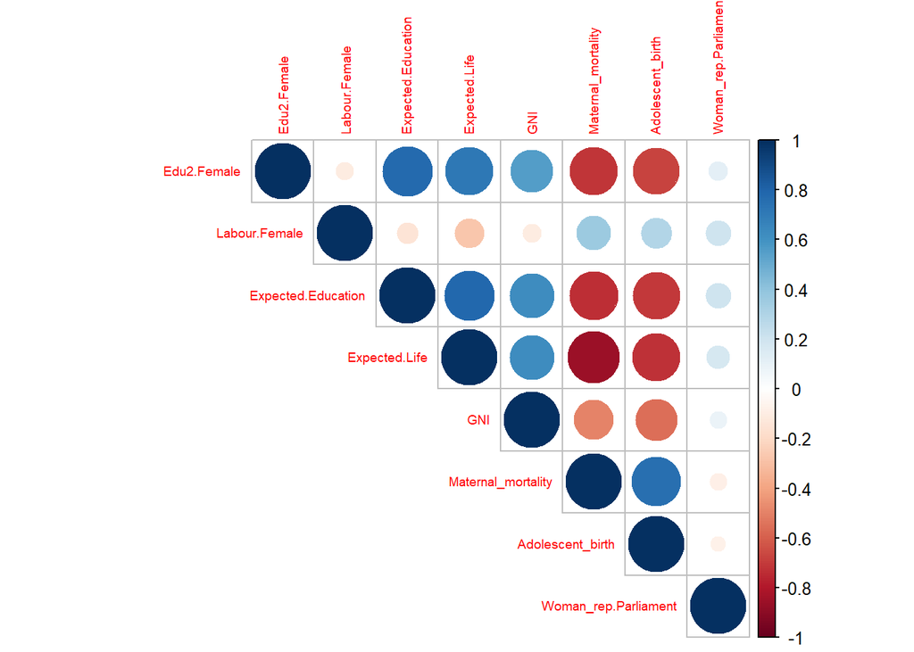

```r
# Compute the correlation matrix and visualize it with corrplot:
cor(human) %>% corrplot(type = "upper", tl.cex=0.6)
```

This figure presents well, that variables ‘Labour.Female’ and ‘Woman_rep.Parliament’ have low correlations with all other variables, but otherwise the variables are correlating with each other quite much.

### Principal Component Analysis (PCA) on the human data

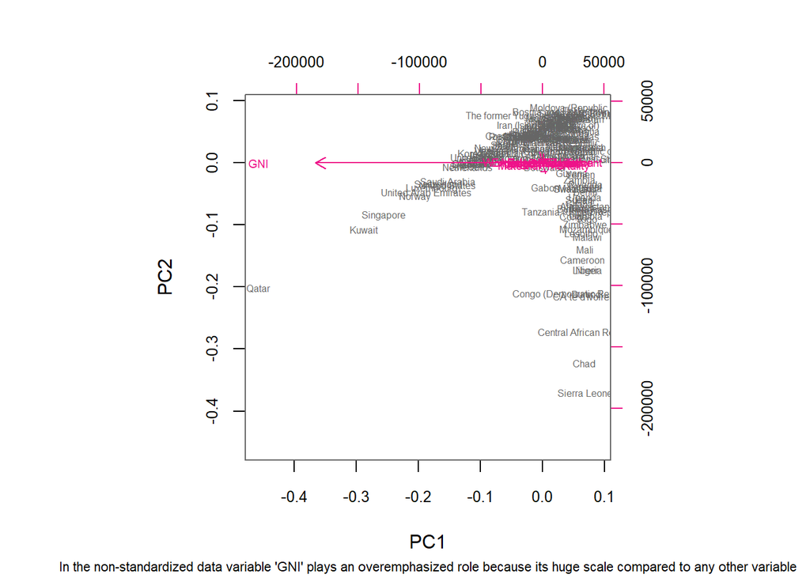

```r
# Perform principal component analysis on the not standardized data (SVD method):
pca_human <- prcomp(human)

# Draw a biplot of the principal component representation and the original variables
biplot(pca_human, choices = 1:2, cex = c(0.5, 0.6), col = c("grey40", "deeppink2"), sub = "In the non-standardized data variable 'GNI' plays an overemphasized role because its huge scale compared to any other variable", cex.sub = 0.7, cex.axis = 0.8)
```

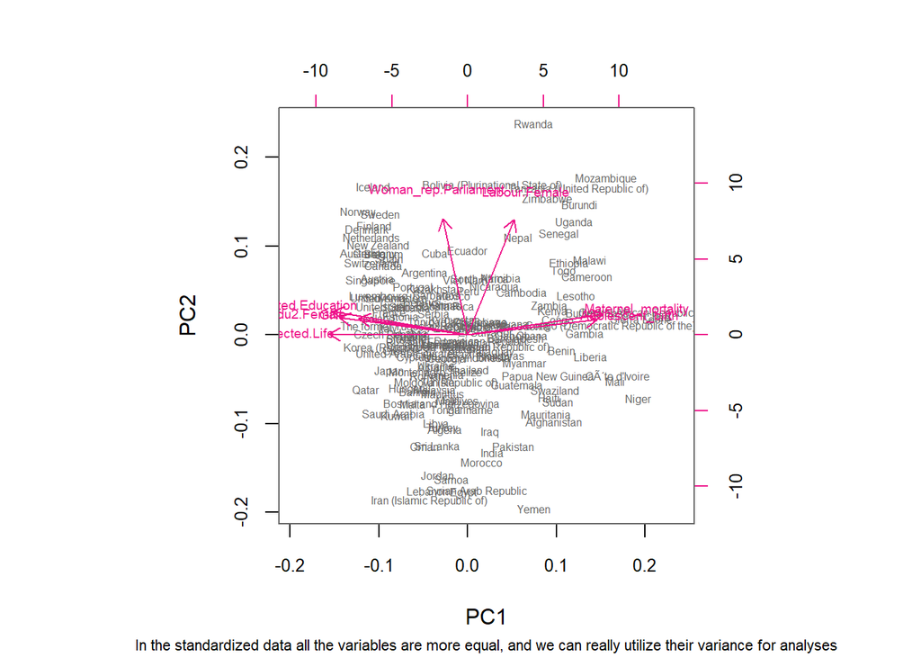

```r
# Standardize the variables:
human_std <- scale(human)

# Perform principal component analysis on the standardized data (SVD method):
pca_human_std <- prcomp(human_std)

# Draw a biplot of the principal component representation and the original variables:
biplot(pca_human_std, choices = 1:2, cex = c(0.5, 0.6), col = c("grey40", "deeppink2"), sub = "In the standardized data all the variables are more equal, and we can really utilize their variance for analyses", cex.sub = 0.7, cex.axis = 0.8)
```

Two figures above shows out how important it is to scale variables before principal component analysis. The latter figure illustrates also well the mutual correlations between some variables, as **in total six original features are contributing on the same dimension**, and therefore we could just pick up one of them to explain most variation of principal component PC1. Just two original features: *female labour and woman reps in parliament*, contribute on the vertical dimension and can explain variation of PC2.

```r
# Calculate summary of principal component analysis:
s <- summary(pca_human_std)

# Calculate and print out rounded percentages of variance captured by each PC:
pca_pr <- round(1*s$importance[2, ]*100, digits = 1)
pca_pr
```

```
##  PC1  PC2  PC3  PC4  PC5  PC6  PC7  PC8
## 57.0 15.6  9.6  6.5  3.8  3.5  2.5  1.4
```

Wow!! **57.0 % of the variation in the data could be explained by just one principal component**. By two components we could explain 72.6 % of the variation.

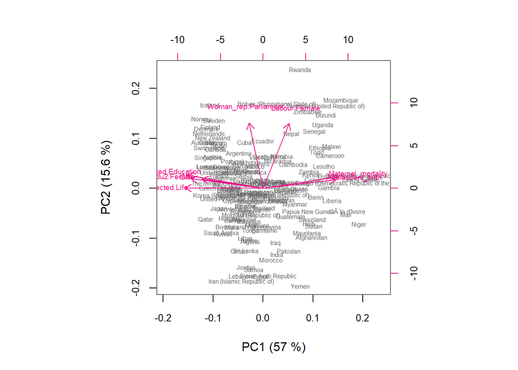

```r
# Let's adjust biplot by creating object 'pc_lab' to be used as axis labels:
pc_lab <- paste0(names(pca_pr), " (", pca_pr, " %)")

# draw a biplot
biplot(pca_human_std, cex = c(0.5, 0.6), col = c("grey40", "deeppink2"), cex.axis = 0.8, xlab = pc_lab[1], ylab = pc_lab[2])
```

### Multiple Correspondence Analysis (MCA) on the tea data

In contrast to PCA, in MCA we can use also **discrete variables**, even at *nominal scale*. For this exercise I load data ‘tea’ from the R package of ‘FactoMineR’.

```r
# Load the tea data:
data("tea")

# Look at the first 3 rows of the data, variable summaries and structure of the data:
head(tea, 3)
```

```
##       breakfast     tea.time     evening     lunch     dinner     always home
## 1     breakfast Not.tea time Not.evening Not.lunch Not.dinner Not.always home
## 2     breakfast Not.tea time Not.evening Not.lunch Not.dinner Not.always home
## 3 Not.breakfast     tea time     evening Not.lunch     dinner Not.always home
##       work     tearoom     friends     resto     pub       Tea   How    sugar
## 1 Not.work Not.tearoom Not.friends Not.resto Not.pub     black alone    sugar
## 2 Not.work Not.tearoom Not.friends Not.resto Not.pub     black  milk No.sugar
## 3     work Not.tearoom     friends     resto Not.pub Earl Grey alone No.sugar
##       how       where      price age sex          SPC     Sport age_Q frequency
## 1 tea bag chain store  p_unknown  39   M       middle sportsman 35-44     1/day
## 2 tea bag chain store p_variable  45   F       middle sportsman 45-59     1/day
## 3 tea bag chain store p_variable  47   F other worker sportsman 45-59    +2/day
##       escape.exoticism     spirituality healthy     diuretic     friendliness
## 1 Not.escape-exoticism Not.spirituality healthy Not.diuretic Not.friendliness
## 2     escape-exoticism Not.spirituality healthy     diuretic Not.friendliness
## 3 Not.escape-exoticism Not.spirituality healthy     diuretic     friendliness
##       iron.absorption     feminine     sophisticated    slimming    exciting
## 1 Not.iron absorption Not.feminine Not.sophisticated No.slimming No.exciting
## 2 Not.iron absorption Not.feminine Not.sophisticated No.slimming    exciting
## 3 Not.iron absorption Not.feminine Not.sophisticated No.slimming No.exciting
##      relaxing    effect.on.health
## 1 No.relaxing No.effect on health
## 2 No.relaxing No.effect on health
## 3    relaxing No.effect on health
```

```r
summary(tea)
```

```
##          breakfast           tea.time          evening          lunch
##  breakfast    :144   Not.tea time:131   evening    :103   lunch    : 44
##  Not.breakfast:156   tea time    :169   Not.evening:197   Not.lunch:256
##
##
##
##
##
##         dinner           always          home           work
##  dinner    : 21   always    :103   home    :291   Not.work:213
##  Not.dinner:279   Not.always:197   Not.home:  9   work    : 87
##
##
##
##
##
##         tearoom           friends          resto          pub
##  Not.tearoom:242   friends    :196   Not.resto:221   Not.pub:237
##  tearoom    : 58   Not.friends:104   resto    : 79   pub    : 63
##
##
##
##
##
##         Tea         How           sugar                     how
##  black    : 74   alone:195   No.sugar:155   tea bag           :170
##  Earl Grey:193   lemon: 33   sugar   :145   tea bag+unpackaged: 94
##  green    : 33   milk : 63                  unpackaged        : 36
##                  other:  9
##
##
##
##                   where                 price          age        sex
##  chain store         :192   p_branded      : 95   Min.   :15.00   F:178
##  chain store+tea shop: 78   p_cheap        :  7   1st Qu.:23.00   M:122
##  tea shop            : 30   p_private label: 21   Median :32.00
##                             p_unknown      : 12   Mean   :37.05
##                             p_upscale      : 53   3rd Qu.:48.00
##                             p_variable     :112   Max.   :90.00
##
```

[output cut: 25 more lines]

```
##  feminine    :129   Not.sophisticated: 85   No.slimming:255   exciting   :116
##  Not.feminine:171   sophisticated    :215   slimming   : 45   No.exciting:184
##
##
##
##
##
##         relaxing              effect.on.health
##  No.relaxing:113   effect on health   : 66
##  relaxing   :187   No.effect on health:234
##
##
##
##
##
```

```r
str(tea)
```

```
## 'data.frame':    300 obs. of  36 variables:
##  $ breakfast       : Factor w/ 2 levels "breakfast","Not.breakfast": 1 1 2 2 1 2 1 2 1 1 ...
##  $ tea.time        : Factor w/ 2 levels "Not.tea time",..: 1 1 2 1 1 1 2 2 2 1 ...
##  $ evening         : Factor w/ 2 levels "evening","Not.evening": 2 2 1 2 1 2 2 1 2 1 ...
##  $ lunch           : Factor w/ 2 levels "lunch","Not.lunch": 2 2 2 2 2 2 2 2 2 2 ...
##  $ dinner          : Factor w/ 2 levels "dinner","Not.dinner": 2 2 1 1 2 1 2 2 2 2 ...
##  $ always          : Factor w/ 2 levels "always","Not.always": 2 2 2 2 1 2 2 2 2 2 ...
##  $ home            : Factor w/ 2 levels "home","Not.home": 1 1 1 1 1 1 1 1 1 1 ...
##  $ work            : Factor w/ 2 levels "Not.work","work": 1 1 2 1 1 1 1 1 1 1 ...
##  $ tearoom         : Factor w/ 2 levels "Not.tearoom",..: 1 1 1 1 1 1 1 1 1 2 ...
##  $ friends         : Factor w/ 2 levels "friends","Not.friends": 2 2 1 2 2 2 1 2 2 2 ...
##  $ resto           : Factor w/ 2 levels "Not.resto","resto": 1 1 2 1 1 1 1 1 1 1 ...
##  $ pub             : Factor w/ 2 levels "Not.pub","pub": 1 1 1 1 1 1 1 1 1 1 ...
##  $ Tea             : Factor w/ 3 levels "black","Earl Grey",..: 1 1 2 2 2 2 2 1 2 1 ...
##  $ How             : Factor w/ 4 levels "alone","lemon",..: 1 3 1 1 1 1 1 3 3 1 ...
```

[output cut: 22 more lines]

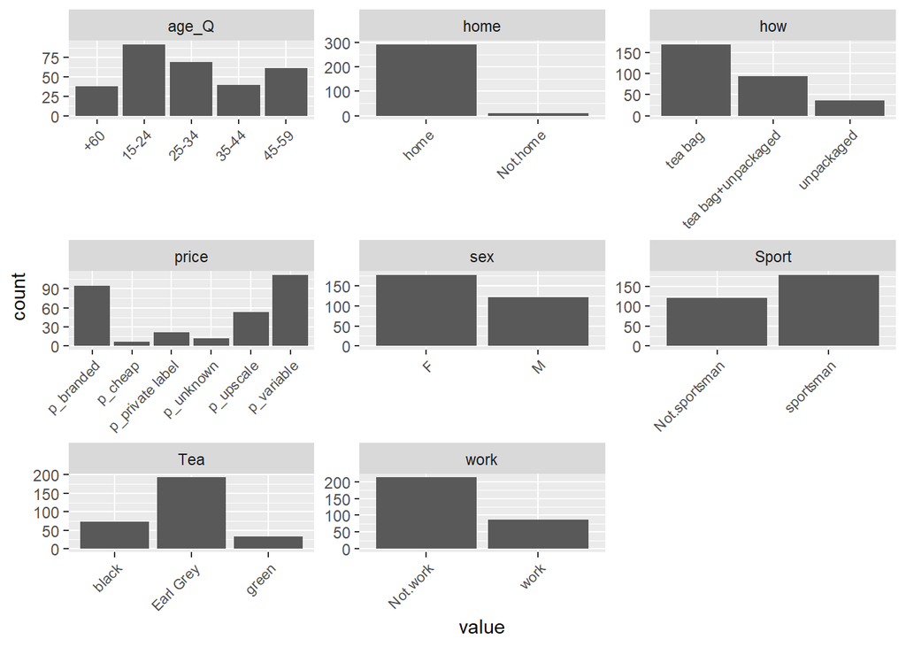

```r
# Select some variables that I'm interested in:
keep_columns <- c("Tea", "how", "home", "work", "price", "sex", "Sport", "age_Q")
tea_selection <- select(tea, one_of(keep_columns))

# Visualize the data of the selected columns
gather(tea_selection) %>% ggplot(aes(value)) + facet_wrap("key", scales = "free") + geom_bar() + theme(axis.text.x = element_text(angle = 45, hjust = 1, size = 8))
```

```r
# Perform Multiple Correspondence Analysis and look at the summary of the model
mca <- MCA(tea_selection, graph = FALSE)
summary(mca)
```

```
##
## Call:
## MCA(X = tea_selection, graph = FALSE)
##
##
## Eigenvalues
##                        Dim.1   Dim.2   Dim.3   Dim.4   Dim.5   Dim.6   Dim.7
## Variance               0.228   0.199   0.165   0.158   0.148   0.143   0.132
## % of var.             10.732   9.360   7.755   7.454   6.971   6.740   6.203
## Cumulative % of var.  10.732  20.092  27.847  35.302  42.272  49.013  55.216
##                        Dim.8   Dim.9  Dim.10  Dim.11  Dim.12  Dim.13  Dim.14
## Variance               0.125   0.119   0.112   0.104   0.100   0.098   0.090
## % of var.              5.900   5.604   5.266   4.905   4.687   4.630   4.231
## Cumulative % of var.  61.116  66.719  71.985  76.891  81.577  86.207  90.438
##                       Dim.15  Dim.16  Dim.17
## Variance               0.080   0.065   0.058
## % of var.              3.780   3.074   2.708
## Cumulative % of var.  94.218  97.292 100.000
##
## Individuals (the 10 first)
##                       Dim.1    ctr   cos2    Dim.2    ctr   cos2    Dim.3
## 1                  |  0.220  0.071  0.010 | -0.044  0.003  0.000 | -0.054
## 2                  |  0.136  0.027  0.013 | -0.143  0.034  0.015 | -0.073
## 3                  | -0.425  0.264  0.134 |  0.171  0.049  0.022 | -0.212
## 4                  | -0.273  0.109  0.069 | -0.212  0.075  0.041 |  0.175
## 5                  | -0.067  0.007  0.004 |  0.146  0.036  0.018 |  0.334
## 6                  | -0.384  0.216  0.061 | -0.046  0.004  0.001 |  0.672
## 7                  | -0.071  0.007  0.003 |  0.132  0.029  0.012 | -0.197
## 8                  |  0.132  0.026  0.010 | -0.157  0.041  0.014 | -0.604
## 9                  |  0.379  0.209  0.070 |  0.464  0.360  0.104 | -0.367
## 10                 |  0.817  0.975  0.270 |  0.089  0.013  0.003 | -0.742
##                       ctr   cos2
## 1                   0.006  0.001 |
## 2                   0.011  0.004 |
## 3                   0.091  0.033 |
## 4                   0.062  0.028 |
## 5                   0.225  0.094 |
## 6                   0.913  0.186 |
## 7                   0.079  0.026 |
## 8                   0.738  0.212 |
```

[output cut: 22 more lines]

```
## home                -5.273 |  -0.048   0.169   0.074  -4.716 |
## Not.home             5.273 |   1.551   5.472   0.074   4.716 |
## Not.work            -6.447 |   0.272   3.995   0.182   7.369 |
## work                 6.447 |  -0.667   9.782   0.182  -7.369 |
##
## Categorical variables (eta2)
##                      Dim.1 Dim.2 Dim.3
## Tea                | 0.420 0.023 0.107 |
## how                | 0.351 0.253 0.122 |
## home               | 0.002 0.093 0.074 |
## work               | 0.116 0.139 0.182 |
## price              | 0.417 0.264 0.121 |
## sex                | 0.092 0.129 0.167 |
## Sport              | 0.019 0.258 0.128 |
## age_Q              | 0.408 0.432 0.416 |
```

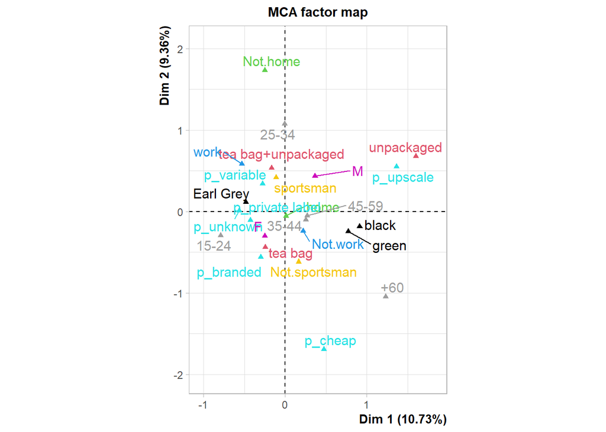

```r
# Visualize MCA
plot(mca, invisible=c("ind"), habillage = "quali")
```

The MCA summary tells that 10.7 % of the data variation could be explained by one dimension, 20.1 % by two dimensions, e.g… In total 17 dimensions are needed for covering all the data variation. The MCA biplot shows the distances between different properties, and we can see that e.g. features ‘p_cheap’ and ‘Not.home’ are far from any other feature. Otherwise we can also see that e.g. people who use unpacked tea, are also ready to buy tea at upscale price. Also we can see how well different dimensions can classify different features: e.g. Earl Grey drinkers can be separated from black and green tea drinkers by using dimension 1, but green and black tea drinkers are difficult to recognize from each other.